# National and Subnational estimates for the United States of America

Subnational estimates Americas United States

Estimates presented here are no longer updated as of 31 March 2022. For more information on the rationale behind this move and some reflections on 2 years of global nowcasting and forecasting, please read our related [blog post](https://epiforecasts.io/posts/2022-03-25-rt-reflections/).

*Using data available up to the:* 2022-03-29

*Subnational and national estimates are available to download [here](https://dataverse.harvard.edu/dataverse/covid-rt).*

*See our see [Methods](https://epiforecasts.io/covid/methods) or our [paper](https://wellcomeopenresearch.org/articles/5-112/) for an explanation of how these estimates are derived.*

## National summary

### Summary (estimates as of the 2022-03-29)

*Table 1: Latest estimates (as of the 2022-03-29) of the number of confirmed cases by date of infection, the expected change in daily confirmed cases, the effective reproduction number, the growth rate, and the doubling time (when negative this corresponds to the halving time). The median and 90% credible interval is shown for each numeric estimate.*

|  | Estimate |
| --- | --- |
| New confirmed cases by infection date | 23348 (13265 – 38617) |
| Expected change in daily cases | Likely decreasing |
| Effective reproduction no. | 0.96 (0.72 – 1.2) |
| Rate of growth | -0.012 (-0.08 – 0.053) |
| Doubling/halving time (days) | -59 (13 – -8.6) |

### Confirmed cases, their estimated date of report, date of infection, and time-varying reproduction number estimates

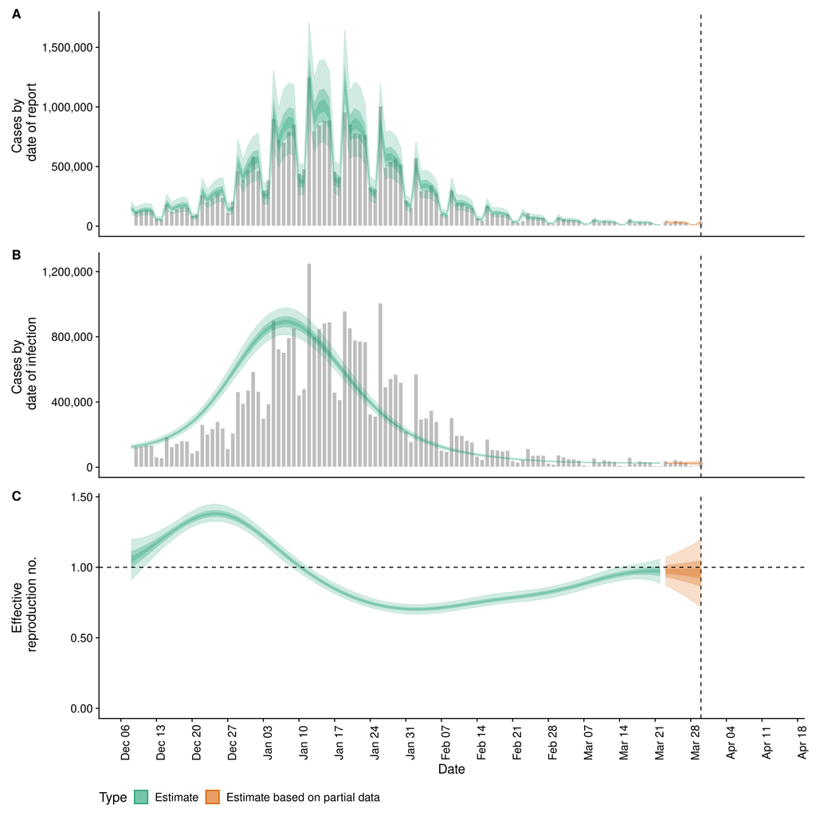

*Figure 1: A.) Confirmed cases by date of report (bars) and their estimated date of report. B.) Confirmed cases by date of report (bars) and their estimated date of infection. C.) Time-varying estimate of the effective reproduction number (lightest ribbon = 90% credible interval; darker ribbon = the 50% credible interval, darkest ribbon = 20% credible interval). Estimates from existing data are shown up to the 2022-03-29 from when forecasts are shown. These should be considered indicative only. Estimates based on partial data have been adjusted for right truncation of infections. The vertical dashed line indicates the date of report generation. Uncertainty has been curtailed to a maximum of ten times the maximum number of reported cases for plotting purposes.*

## Subnational breakdown

[interactive chart not shown]

*Figure 2: The results of the latest reproduction number estimates (based on confirmed cases in United States, stratified by State, can be summarised by whether confirmed cases are likely increasing or decreasing. This represents the strength of the evidence that the reproduction number in each region is greater than or less than 1, respectively (see the [methods](https://epiforecasts.io/covid/methods.html) for details).*

| State | New confirmed cases by infection date | Expected change in daily cases | Effective reproduction no. | Rate of growth | Doubling/halving time (days) | New confirmed cases by infection date | Effective reproduction no. | Rate of growth | Doubling/halving time (days) |
| --- | --- | --- | --- | --- | --- | --- | --- | --- | --- |
| Alabama | 366 (73 -- 2748) | Stable | 1 (0.58 -- 1.9) | 0.006 (-0.12 -- 0.24) | 120 (2.9 -- -5.6) | 366 | 1 | 0.006 | 120 |
| Alaska | 60 (4 -- 1024) | Likely decreasing | 0.77 (0.28 -- 1.7) | -0.065 (-0.23 -- 0.18) | -11 (3.9 -- -3) | 60 | 0.77 | -0.065 | -11 |
| American Samoa | 1339 (261 -- 7930) | Likely increasing | 1.5 (0.99 -- 2.1) | 0.14 (-0.0034 -- 0.27) | 5.1 (2.5 -- -210) | 1339 | 1.5 | 0.14 | 5.1 |
| Arizona | 14 (2 -- 132) | Likely decreasing | 0.57 (0.28 -- 1.1) | -0.13 (-0.23 -- 0.038) | -5.5 (18 -- -3) | 14 | 0.57 | -0.13 | -5.5 |
| Arkansas | 56 (10 -- 269) | Decreasing | 0.53 (0.23 -- 0.94) | -0.14 (-0.25 -- -0.016) | -5 (-44 -- -2.7) | 56 | 0.53 | -0.14 | -5 |
| California | 1613 (364 -- 7574) | Likely decreasing | 0.81 (0.45 -- 1.3) | -0.055 (-0.17 -- 0.087) | -13 (8 -- -4.1) | 1613 | 0.81 | -0.055 | -13 |
| Colorado | 783 (176 -- 3767) | Likely decreasing | 0.94 (0.56 -- 1.4) | -0.018 (-0.13 -- 0.12) | -39 (5.9 -- -5.3) | 783 | 0.94 | -0.018 | -39 |
| Connecticut | 340 (109 -- 1254) | Stable | 0.98 (0.66 -- 1.5) | -0.0054 (-0.1 -- 0.12) | -130 (5.7 -- -6.9) | 340 | 0.98 | -0.0054 | -130 |
| Delaware | 98 (42 -- 254) | Likely increasing | 1.1 (0.73 -- 1.6) | 0.017 (-0.078 -- 0.14) | 41 (4.8 -- -8.9) | 98 | 1.1 | 0.017 | 41 |
| District of Columbia | 2572 (239 -- 39874) | Likely increasing | 1.5 (0.83 -- 2.8) | 0.14 (-0.049 -- 0.42) | 5 (1.7 -- -14) | 2572 | 1.5 | 0.14 | 5 |

[output cut: 46 more lines]

*Table 2: Latest estimates (as of the 2022-03-29) of the number of confirmed cases by date of infection, the effective reproduction number, the rate of growth, and the doubling time (when negative this corresponds to the halving time) in each region. The median and 90% credible interval is shown.*

### Data availability

- Case counts by date, stratified by region, were downloaded from a publically available source curated by Johns Hopkins University (“2019 Novel Coronavirus COVID-19 (2019-nCoV) Data Repository” 2020; Abbott et al. 2020).
- Case onset dates were estimated using case counts by date of report and a distribution of reporting delays fitted to a publically available line-list of international cases (Xu et al., n.d.; Abbott et al. 2020).

### Limitations

- Line-list data to inform a State specific estimates of the reporting delay were not available.

“2019 Novel Coronavirus COVID-19 (2019-nCoV) Data Repository.” 2020. Johns Hopkins CSSE. https://github.com/CSSEGISandData/COVID-19.

Abbott, Sam, Katharine Sherratt, Jonnie Bevan, Hamish Gibbs, Joel Hellewell, James Munday, Patrick Barks, Paul Campbell, Flavio Finger, and Sebastian Funk. 2020. “Covidregionaldata: Subnational Data for the Covid-19 Outbreak.” *-* - (-): –. https://doi.org/10.5281/zenodo.3957539.

Xu, Bo, Bernardo Gutierrez, Sarah Hill, Samuel Scarpino, Alyssa Loskill, Jessie Wu, Kara Sewalk, et al. n.d. “Epidemiological Data from the nCoV-2019 Outbreak: Early Descriptions from Publicly Available Data.” http://virological.org/t/epidemiological-data-from-the-ncov-2019-outbreak-early-descriptions-from-publicly-available-data/337.

Share: